# An introduction to ss3sim for stock assessment simulation testing

2017-04-18

# 1 Installing the ss3sim R package

ss3sim requires R version 3.1.0 or greater. The package can be run on OS X, Windows, or Linux. The CRAN version of ss3sim can be installed in an R console with:

```r
install.packages("ss3sim")
```

The development version of ss3sim can be installed from GitHub with the following code:

```r
# install.packages("devtools") # if needed
devtools::install_github("ss3sim/ss3sim", dependencies = TRUE)

# If you would like the vignettes available with the GitHub development version:
devtools::install_github("ss3sim/ss3sim", dependencies = TRUE, build_vignettes = TRUE)

# If you would like to run simulations in parallel, also install:
install.packages(c("doParallel", "foreach"))
```

You can then load the package with:

```r
library("ss3sim")
```

You can read the help files and access the various vignettes (including this one) with:

```r
?ss3sim
help(package = "ss3sim")
browseVignettes("ss3sim")
```

See Anderson et al. (2014) for a more formal (but brief) overview of ss3sim.

We develop and test ss3sim around a specific version of SS3. Currently, ss3sim is tested to work with SS3 Version 3.24O. Since this is a more recent version than is provided at the normal download location http://nft.nefsc.noaa.gov/SS3.html, we provide copies of the 3.24O binaries (with the permission of R. Methot) at https://www.dropbox.com/sh/zg0sec6j20sfyyz/AACQiuk787qW882U2euVKoPna.

There are two versions of the binary: safe and optimized (‘opt’). The difference is in how the ADMB source code for SS3 is compiled. If it is in safe mode, then the program will check that vector, matrix, or array bounds are not exceeded. There is a slight overhead in this checking, but it may help identify issues. The optimized version skips this check, running a bit faster but without the safety net. By default ss3sim uses the safe binary but the user can opt for the optimized version. See the `ss_mode` argument for `run_ss3model`. ss3sim requires the SS3 binary to be in your path. This means that your operating system knows where the binary file is located. See the vignette section on paths for details. See `?run_ss3model` for instructions on how to specify the safe vs. the optimized binary.

Please direct any questions, suggestions, or bug reports to the ss3sim issue tracker: https://github.com/ss3sim/ss3sim/issues, or to an author as listed on the title page of this vignette.

If you use ss3sim in a publication, please cite the package as indicated by running `citation("ss3sim")` in the R console:

```r
citation("ss3sim")
```

```
#>
#>
#>   Anderson, SC, Monnahan, CC, Johnson, KF, Ono, K, Valero, JL,
#>   Cunningham, CJ, Hurtado-Ferro, F, Kuriyama, P, Licandeo, R,
#>   McGilliard, CR, Rudd, M, Stawitz, CC, Szuwalski, CS, Taylor, IG,
#>   Vert-pre, KA, and Whitten, AR (2017). ss3sim: Fisheries Stock
#>   Assessment Simulation Testing with Stock Synthesis. R package
#>   version 0.9.3.9002.
#>
#>   Anderson, SC, Monnahan, CC, Johnson, KF, Ono, K, and Valero, JL
#>   (2014). ss3sim: An R package for fisheries stock assessment
#>   simulation with Stock Synthesis. PLOS ONE. 9(4): e92725.
#>   http://doi.org/10.1371/journal.pone.0092725.
```

# 2 An overview of the ss3sim simulation structure

ss3sim is an R package to make it relatively quick and easy to run simulations with the 3rd version of Stock Synthesis, SS3. The package consists of a series of low-level functions that facilitate manipulating SS3 configuration files, running SS3 models, and combining the output. ss3sim also contains some wrapper functions that tie all these low-level functions together into a complete simulation experiment. If you choose to use our wrapper function `run_ss3sim` then you will use a series of plain text control files to control the simulation. Much of this vignette focusses on how to effectively use `run_ss3sim`, but feel free to take the low-level functions (`change` functions) and use them as part of your own flexible simulation.

## 2.1 Setting up the file structure

The ss3sim package is set up assuming there is an established base-case operating model (OM) and estimation model (EM) to work with. The ss3sim package comes with three generic built-in model setups that can be used as is, modified, or replaced. (For more details, see the vignette on modifying these model setups or the vignette on creating your own OM and EMs). Each OM and EM should be in its own folder. The OM folder should have the files:

```
yourOMmodel.ctl
yourOMmodel.dat
ss3.par
starter.ss
forecast.ss
```

The EM folder should have:

```
yourEMmodel.ctl
starter.ss
forecast.ss
```

In both cases, nothing more and nothing less. The names of the `.ctl` and `.dat` files are not important. The package functions will rename them after they are copied to appropriate folders. These files should be derived from `.ss_new` files but with file extensions as shown above. It is important to use `.ss_new` files so the files have consistent formatting. Many of the functions in this package depend on that formatting.

To obtain `.ss_new` files, open a command window in the OM and EM folders and type `ss3_24o_safe` to run the models. Once the model is finished running, it will generate a number of files, including `.ss_new` files. Remove the `.ss_new` file extension from the files needed and add the appropriate file extension.

## 2.2 Cases and scenarios

The high-level wrapper function `run_ss3sim` uses unique case identifiers (IDs) that combine to create unique scenarios. The types of cases are: data quality (D), estimation (E), fishing mortality (F), retrospective (R), and any other letter describing a time varying case (e.g. M for natural mortality, S for selectivity, or G for growth). These case IDs are followed by an alphanumeric stock or species identifier (e.g. `cod`). The different versions of each case are identified with numbers. For example, the base-case scenario for a cod stock might be: `D0-E0-F0-M0-cod`. The order of the cases does not matter, as long as they are used consistently.

ss3sim relies on a set of plain text files to control the simulation. These plain text files are read by `get_caseval` and turned into argument lists that are passed to `run_ss3sim`. The function `create_argfiles` creates template input files. It reads the various functions and parses the arguments and default values into plain text files. The default settings create these files:

1. `E0-spp.txt` (for estimation method cases)
2. `F0-spp.txt` (for fishing mortality cases)
3. `index0-spp.txt` (controlled by the `D` (data) case)
4. `agecomp0-spp.txt` (controlled by the `D` (data) case)
5. `lcomp0-spp.txt` (controlled by the `D` (data) case)
6. `X0-spp.txt` (for a time-varying parameter X, where X could be any time-varying case letter)

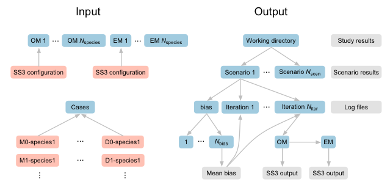

Illustration of input and output folder and file structure for an ss3sim simulation. Folders are shown in blue, input files in orange, and output files in grey. All input and output files are in plain text format. Case files (orange files at bottom left) combine cases (e.g. M0 for a given natural mortality trajectory) with species or life-history OMs and EMs (e.g. cod-like or sardine-like). Alternatively, a user can skip setting up case files and specify the simulation cases directly in R code (see the vignette section on using ss3sim_base()

The first column in the text files denotes the argument to be passed to a function. The second argument denotes the value to be passed. See the help for a `change` function to see the arguments that need to be declared. For example, see `?change_f`.

You can use any R syntax to declare argument values. For example, `c(1, 2, 4)`, or `seq(1, 100)`. Character objects do not need to be quoted as long as they are one word, but can be if you would like. However, be careful not to use the delimiter (set up as a semicolon) anywhere else in the file besides to denote columns. You can add comments after any `#` symbol.

Putting that all together, below is what an example `F1-cod.txt` file might look like:

```
 years; 1913:2012
 years_alter; 1913:2012
 fvals; c(rep(0, 25), rep(0.114, 75))
```

## 2.3 Case file names

Function names and associated case files. Case file names are given as the prefix. For example a case file for `sample_index` might be `index0-cod.txt`.

| ss3sim function | Case file name | Description |
| --- | --- | --- |
| `change_f()` | `F` | Fishing mortality (mandatory) |
| `sample_index()` | `index` | Index data (mandatory) |
| `sample_lcomp()` | `lcomp` | Length composition data (mandatory) |
| `sample_agecomp()` | `agecomp` | Age composition data (mandatory) |
| `change_r()` | `retro` | Retrospective years |
| `change_e()` | `E` | Estimation |
| `change_tv()` | anything else, see below | Time-varying variables |
| `change_data()` | `data` | Available OM data, bins, etc. |
| `sample_calcomp()` | `calcomp` | Catch at length data |
| `sample_wtatage()` | `wtatage` | Weight at age data |
| `sample_mlacomp()` | `mlacomp` | Mean length at age data |

`change_tv()` can take any other case file name, as long as the first line is `function_type; change_tv`.

## 2.4 Bias adjustment

Bias adjustment helps assure that the estimated log-normally distributed recruitment deviations are mean-unbiased leading to mean-unbiased estimates of biomass (Methot and Taylor 2011). The high-level wrapper function `run_ss3sim` allows users to specify whether or not they would like to use the bias adjustment routine built into the package by setting the argument `bias_adjust` to `TRUE` or `FALSE`. If `TRUE`, the function runs `bias_nsim` replicates for each scenario (located in the subfolder `bias` within a scenario folder) and then averages the bias-adjustment parameter estimates. The default number of bias-adjustment replicates is five. If a bias-adjustment replicate fails to converge (checked by identifying whether the Hessian was invertible), the parameter estimates from that replicate are ignored. A minimum threshold of 80% converged bias-adjustment replicates (adjustable via the `conv_crit` argument) is used to ensure reliable parameter estimates. The mean bias adjustment runs are then used in the EM for all subsequent “iterations” (i.e. replicates using same models but different process and observation errors) within that scenario. We assume bias adjustment parameters applicable to all iterations within the scenario are more likely to be found by averaging across multiple sets of parameters.

The bias adjustment process creates several files in the `bias` folder (for each scenario) which can be examined by the user. `AdjustBias.DAT` contains the calculated adjustment parameters for each bias replicate, and `AvgBias.DAT` contains the average of these estimates which are used in all subsequent simulations for that scenario. Individual plots for each successful bias adjustment replicate are also created. If `bias_adjust` is set to `FALSE`, no bias adjustment replicates are executed and no bias adjustment is performed.

## 2.5 Output file structure

Internally, the function `copy_ss3models` creates a folder structure and copies the operating and estimation models. The folder structure looks like:

```
  D0-E0-F0-M0-cod/1/om
  D0-E0-F0-M0-cod/1/em
  D0-E0-F0-M0-cod/2/om
  D0-E0-F0-M0-cod/2/em
  ...
```

The integer values after the scenario ID represent different iterations; the total number of iterations run are specified by the user. If you are using bias adjustment (`bias_adjust = TRUE`) then there will be some additional folders. In that case the folders will look like:

```
  D0-E0-F0-M0-cod/bias/1/om
  D0-E0-F0-M0-cod/bias/1/em
  D0-E0-F0-M0-cod/bias/2/om
  D0-E0-F0-M0-cod/bias/2/em
  ...
  D0-E0-F0-M0-cod/1/om
  D0-E0-F0-M0-cod/1/em
  D0-E0-F0-M0-cod/2/om
  D0-E0-F0-M0-cod/2/em
  ...
```

Note that the OM and EM folders will be renamed `om` and `em` within each iteration, the OM and EM are checked to make sure they contain the minimal files (as listed above), the filenames will be all lowercase, the data file is renamed `ss3.dat`, the control files are renamed `om.ctl` or `em.ctl`, and the starter and control files are adjusted to reflect these new file names. The functions in this package assume you have set your working directory in R to be the base folder where you will store the scenario folders.

# 3 An example simulation with ss3sim

As an example, we will run a 2x2 simulation design in which we test (1) the effect of high and low precision on the index of abundance research survey and (2) the effect of fixing versus estimating natural mortality (*M*). All of the required files for this example are contained within the ss3sim package. To start, we will locate three sets of folders: the folder with the plain text case files, the folder with the OM, and the folder with the EM.

```r
library(ss3sim)
d <- system.file("extdata", package = "ss3sim")
case_folder <- paste0(d, "/eg-cases")
om <- paste0(d, "/models/cod-om")
em <- paste0(d, "/models/cod-em")
```

See the folder `ss3sim/inst/extdata/eg-cases` inside the ss3sim source code for all the case files that are used in this example simulation. You can either download the source code from https://github.com/ss3sim/ss3sim or find this folder at the location contained in the `case_folder` object defined in the block of R code above this paragraph.

## 3.1 Creating the case files

We will base the simulation around the base-case files created for a cod-like species in the papers Ono et al. (2015) and Johnson et al. (2015), both of which used the ss3sim package. You can refer to these papers for details on how the models were set up.

If we were starting from scratch, we would run the function `create_argfiles()`, which would create a default set of configuration files in our R working directory. Instead we will start with the configuration files from those papers.

The file `index0-cod.txt` will therefore look like:

```
fleets;  2
years;   list(seq(1974, 2012, by = 2))
sds_obs; list(0.1)
```

`fleets` refers to the fleet number we want to sample from (as defined in the model), `2` in `codOM.dat` refers to the survey fleet. We then run our survey from 1974 to 2012 with a standard error on the log(survey index) of 0.1.

We will not describe the length or age composition sampling here in detail, but you can refer to the help files `?sample_lcomp` and `?sample_agecomp` along with the case files included in the package data. Also see vignette section where we describe the theory behind the age- and length-composition sampling in ss3sim.

To investigate the effect of fixing versus estimating *M*, we will manipulate the argument `natM_val` that gets passed to `change_e`. The first entry of `natM_val` is the value which *M* is fixed or initialized at and the second refers the phase. In case 0, we will set the phase in which *M* is estimated to `-1` (any negative phase number will tell SS3 to not estimate a particular parameter) and use the argument `NA` to fix *M* at the true value (i.e. do not modify it from what is in the EM `.ctl` file). In case 1, we will estimate *M* in phase `3` and initialize the estimation of *M* at `0.20`. We can do this by including the line: `natM_val; c(NA, -1)` in the file `E0-cod.txt` and the line: `natM_val; c(0.20, 3)` in the file `E1-cod.txt`. This means that case `E1` will initialize *M* at `0.20` and estimate *M* in the third phase. For example, the complete case file `E0-cod.txt` is:

```
natM_type;          1Parm
natM_n_breakpoints; NULL
natM_lorenzen;      NULL
natM_val;           c(NA,-1)
par_name;           LnQ_base_3_CPUE
par_int;            NA
par_phase;          -1
forecast_num;       0
```

We will set the fishing mortality $F$ to a constant level at $F_\mathrm{MSY}$ ($F$ at maximum sustainable yield) from when the fishery starts (in year 25) until the end of our simulation (year 100). Therefore, this is our `F0-cod.txt`:

```
years;       1913:2012
years_alter; 1913:2012
fvals;       c(rep(0,25), rep(0.114,75))
```

Although we do not have any time-varying processes in this example simulation, we include `M` case files in which we describe *M* as stationary (`M0-cod.txt`):

```
function_type; change_tv
param;         NatM_p_1_Fem_GP_1
dev;           rep(0, 100)
```

Simply by changing the deviations from a vector of zeros to any vector pattern of deviations, we could add time-varying *M*. In a [later vignette section]((#time-varying) we describe how time-varying parameters are unique in ss3sim and how you can make any parameter described in SS3 time varying using this approach.

## 3.2 Checking the case files

It is a good idea to check that the case files are manipulating the SS3 model files as intended. One way we can do this is by running the `change` functions directly on the SS3 model files using the arguments specified within the case files and inspecting the modified SS3 files. Another way is to run a single iteration of your simulation through `run_ss3sim` and carefully inspect the OM and EM model files that it creates. For example, we could run:

```r
run_ss3sim(iterations = 1, scenarios =
  c("D0-E0-F0-M0-cod",
    "D1-E0-F0-M0-cod",
    "D0-E1-F0-M0-cod",
    "D1-E1-F0-M0-cod"),
  case_files = list(F = "F", D = c("index", "lcomp", "agecomp"),
    E = "E", M = "M"),
  case_folder = case_folder, om_dir = om,
  em_dir = em)
```

And then check the SS3 files that are created.

## 3.3 Self testing: deterministic simulations to check the models for bias

Self testing is a crucial step of any simulation study. One way to accomplish this is to set up an EM that is similar to the OM and include minimal error.

We will run some simulations to check our EM for bias when process and observation error are minimized. To do this, we will start by setting up a 100 row (number of years) by 20 column (number of iterations) matrix of recruitment deviations, where all values are set to zero.

```r
recdevs_det <- matrix(0, nrow = 100, ncol = 20)
```

Then we will set up case “estimation” files in which the initialized values of the recruitment deviation standard deviations, `SR_sigmaR`, are set to the nominal level of `0.001`. We will name these files `E100-cod.txt` and `E101-cod.txt`. In the case files, the key element is setting `par_name = SR_sigmaR` (the SS3 parameter name) and `par_int = 0.001` (the initial value). The arguments `par_name` and `par_int` are set up to handle vectors of parameter names and values. In this example, changing `SR_sigmaR` will be the second parameter in the vector. Again, you can look at all the case files in the package folder `/inst/extdata/eg-cases/`. As an example, here is the file `E101-cod`:

```
natM_type;          1Parm
natM_n_breakpoints; NULL
natM_lorenzen;      NULL
natM_val;           c(0.20,3)
par_name;           LnQ_base_3_CPUE,SR_sigmaR
par_int;            c(NA,0.001)
par_phase;          c(-1,-1)
forecast_num;       0
```

To minimize observation error on the survey index, we will create a data case 100 that has a standard deviation on the survey observation error of 0.001. Therefore, our case file `index100-cod.txt` will look like this:

```
fleets;  2
years;   list(seq(1974, 2012, by = 2))
sds_obs; list(0.001)
```

When we run the simulations, we will pass our deterministic recruitment deviations to the function `run_ss3sim`. Running 20 iterations should be enough to identify whether our models are performing as we expect. Note that by default 5 bias adjustment runs are performed since we specify that `bias_adjust=TRUE`.

```r
run_ss3sim(iterations = 1:20,
  scenarios = c("D100-E100-F0-M0-cod", "D100-E101-F0-M0-cod"),
  case_files = list(F = "F", D = c("index", "lcomp", "agecomp"),
    E = "E", M = "M"),
  case_folder = case_folder, om_dir = om, em_dir = em,
  bias_adjust = TRUE, user_recdevs = recdevs_det)
```

We have written out the scenario names in full for clarity, but ss3sim also contains a convenience function `expand_scenarios`. With this function we could instead write:

```r
x <- expand_scenarios(list(D = 100, E = 100:101, F = 0, M = 0),
  species = "cod")
run_ss3sim(iterations = 1:20, scenarios = x,
  case_folder = case_folder, om_dir = om, em_dir = em,
  bias_adjust = TRUE, user_recdevs = recdevs_det,
  case_files = list(F = "F", D = c("index", "lcomp", "agecomp"),
    E = "E", M = "M"))
```

Note that due to the way that SS3 is being used as an operating model, you may see an ADMB error in the console:

```
Error -- base = 0 in function prevariable& pow(const prevariable& v1,
  CGNU_DOUBLE u)
```

However, this is not a problem since ADMB is not used to optimize the OM — the error can safely be ignored.

## 3.4 Running the stochastic simulations

We will only run 100 iterations here to save time and keep the package size down, but in a real simulation testing study you may want to run many more iterations, perhaps testing how many iterations are required before the key results stabilize.

```r
run_ss3sim(iterations = 1:100, scenarios =
  c("D0-E0-F0-M0-cod",
    "D1-E0-F0-M0-cod",
    "D0-E1-F0-M0-cod",
    "D1-E1-F0-M0-cod"),
  case_files = list(F = "F", D = c("index", "lcomp", "agecomp"),
    E = "E", M = "M"),
  case_folder = case_folder, om_dir = om,
  em_dir = em, bias_adjust = TRUE)
```

## 3.5 Reading in the output and plotting the results

The function `get_results_all` reads in a set of scenarios

and combines the output into two `.csv` files: `ss3sim_scalar.csv` and `ss3sim_ts.csv`. The `scalar` file contains values for which there is a single estimated value (e.g. MSY) and the `ts` file refers to values for which there are time series of estimates available (e.g. biomass for each year). The column names refer to the output from SS3, so it can be useful to consult the SS3 manual for details.

```r
get_results_all(user_scenarios =
  c("D100-E100-F0-M0-cod",
    "D100-E101-F0-M0-cod",
    "D0-E0-F0-M0-cod",
    "D1-E0-F0-M0-cod",
    "D0-E1-F0-M0-cod",
    "D1-E1-F0-M0-cod"))
```

We will read in the `.csv` files:

```r
scalar_dat <- read.csv("ss3sim_scalar.csv")
ts_dat <- read.csv("ss3sim_ts.csv")
```

Or if you would like to follow along with the rest of the vignette without running the simulations above, you can load a saved version of the output:

```r
data("ts_dat", package = "ss3sim")
data("scalar_dat", package = "ss3sim")
```

First, we will calculate some useful values in new columns and separate the deterministic from the stochastic simulation runs:

```r
scalar_dat <- transform(scalar_dat,
  steep = (SR_BH_steep_om - SR_BH_steep_em)/SR_BH_steep_om,
  logR0 = (SR_LN_R0_om - SR_LN_R0_em)/SR_LN_R0_om,
  depletion = (depletion_om - depletion_em)/depletion_om,
  SSB_MSY = (SSB_MSY_em - SSB_MSY_om)/SSB_MSY_om,
  SR_sigmaR = (SR_sigmaR_em - SR_sigmaR_om)/SR_sigmaR_om,
  NatM = (NatM_p_1_Fem_GP_1_em - NatM_p_1_Fem_GP_1_om)/
     NatM_p_1_Fem_GP_1_om)

ts_dat <- transform(ts_dat,
  SpawnBio = (SpawnBio_em - SpawnBio_om)/SpawnBio_om,
  Recruit_0 = (Recruit_0_em - Recruit_0_om)/Recruit_0_om)
ts_dat <- merge(ts_dat, scalar_dat[,c("scenario", "replicate",
    "max_grad")])

scalar_dat_det <- subset(scalar_dat, E %in% c("E100", "E101"))
scalar_dat_sto <- subset(scalar_dat, E %in% c("E0", "E1"))
ts_dat_det <- subset(ts_dat, E %in% c("E100", "E101"))
ts_dat_sto <- subset(ts_dat, E %in% c("E0", "E1"))
```

Now we will turn the scalar data into long-data format so we can make a multipanel plot with the R package ggplot2.

```r
scalar_dat_long <- reshape2::melt(scalar_dat[,c("scenario", "D", "E",
  "replicate", "max_grad", "steep", "logR0", "depletion", "SSB_MSY",
  "SR_sigmaR", "NatM")], id.vars = c("scenario", "D", "E",
  "replicate", "max_grad"))
scalar_dat_long <- plyr::rename(scalar_dat_long,
  c("value" = "relative_error"))
```

Now we can create boxplots of the deterministic model runs.

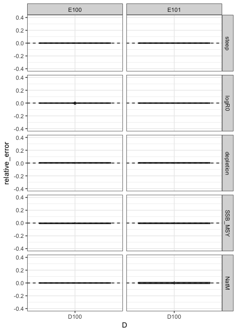

Relative error box plots for deterministic runs. In case E100, *M* is fixed at the true value; in E101 we estimate *M*. In case D100, the standard deviation on the survey index observation error is 0.001.

```r
library("ggplot2")
p <- ggplot(subset(scalar_dat_long, E %in% c("E100", "E101") &
       variable != "SR_sigmaR"), aes(D, relative_error)) +
     geom_boxplot() +
     geom_hline(aes(yintercept = 0), lty = 2) +
     facet_grid(variable~E) +
     theme_bw() + ylim(-0.4, 0.4)
print(p)
```

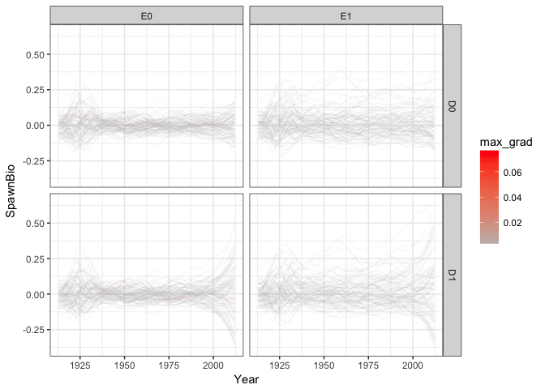

Time series of relative error in spawning stock biomass.

```r
p <- ggplot(ts_dat_sto, aes(x = year)) + xlab("Year") +
    theme_bw() + geom_line(aes(y = SpawnBio, group = replicate,
    colour = max_grad), alpha = 0.3, size = 0.15) + facet_grid(D~E) +
    scale_color_gradient(low = "gray", high = "red")
print(p)
```

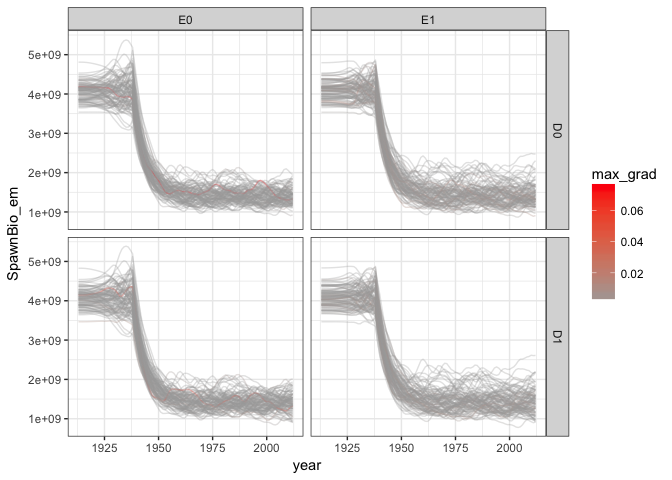

Spawning stock biomass time series.

```r
p <- ggplot(ts_dat_sto, aes(year, SpawnBio_em, group = replicate)) +
  geom_line(alpha = 0.3, aes(colour = max_grad)) + facet_grid(D~E) +
  scale_color_gradient(low = "darkgrey", high = "red") + theme_bw()
print(p)
```

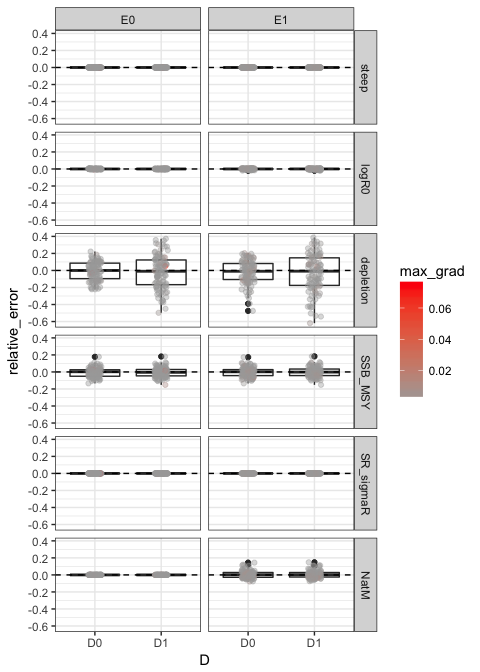

Relative error box plots for stochastic runs. In case E0, *M* is fixed at the true value; in E1 we estimate *M*. In case D1, the standard deviation on the survey index observation error is 0.4. In case D0, the standard deviation is quartered representing an increase in survey sampling effort.

```r
p <- ggplot(subset(scalar_dat_long, E %in% c("E0", "E1")),
       aes(D, relative_error)) +
     geom_boxplot() + geom_hline(aes(yintercept = 0), lty = 2) +
     facet_grid(variable~E) +
     geom_jitter(aes(colour = max_grad),
       position = position_jitter(height = 0, width = 0.1),
       alpha = 0.4, size = 1.5) +
     scale_color_gradient(low = "darkgrey", high = "red") +
     theme_bw()
print(p)
```

# 4 Using ss3sim_base directly

An alternative approach to using ss3sim is to skip setting up the case files and use `ss3sim_base` directly by passing lists of arguments. The lists correspond to the arguments to each of the `change` or `sample` functions without any references to the files that need to be modified. (Although if you passed the file names they would just be ignored.) The documentation for each function includes an asterisk beside the arguments that you can specify. Note that if you do not include an argument then `ss3sim_base` will assume the value of that argument is `NULL`.

```r
d <- system.file("extdata", package = "ss3sim")
om <- paste0(d, "/models/cod-om")
em <- paste0(d, "/models/cod-em")

F0 <- list(years = 1913:2012, years_alter = 1913:2012, fvals =
  c(rep(0, 25), rep(0.114, 75)))

index1 <- list(fleets = 2, years = list(seq(1974, 2012, by = 2)),
  sds_obs = list(0.1))

lcomp1 <- list(fleets = c(1, 2), Nsamp = list(100, 100), years =
  list(1938:2012, seq(1974, 2012, by = 2)), lengthbin_vector = NULL,
  cpar = c(1, 1))

agecomp1 <- list(fleets = c(1, 2), Nsamp = list(100, 100), years =
  list(1938:2012, seq(1974, 2012, by = 2)), agebin_vector = NULL,
  cpar = c(1, 1))

E0 <- list(natM_type = "1Parm", natM_n_breakpoints = NULL,
  natM_lorenzen = NULL, natM_val = c(NA,-1), par_name =
  "LnQ_base_3_CPUE", par_int = NA, par_phase = -1, forecast_num = 0)

M0 <- list(NatM_p_1_Fem_GP_1 = rep(0, 100))

ss3sim_base(iterations = 1:20, scenarios = "D1-E0-F0-M0-cod",
  f_params = F0, index_params = index1, lcomp_params = lcomp1,
  agecomp_params = agecomp1, estim_params = E0, tv_params = M0,
  om_dir = om, em_dir = em)
```

# 5 An example of customizing the case specifications

You do not need to stick with the scenario ID scheme laid out by default in ss3sim. You are free to choose your own scheme by adjusting the list of values passed to the `case_files` argument in `run_ss3sim()`.

Below is an example where we’ll specify the arguments to the sampling functions via their own case files. We’ll arbitrarily call these cases X, Y, and Z.

We will start by copying over some case arguments built into the package. We will copy what was called `index0-cod.txt`, `lcomp0-cod.txt`, and `agecomp0-cod.txt` into `X-cod.txt`, `Y-cod.txt`, and `Z-cod.txt`. Then we’ll set up our custom `case_files` list and call `run_ss3sim()`:

```r
case_folder <- system.file("extdata", "eg-cases", package = "ss3sim")
om <- system.file("extdata", "models/cod-om", package = "ss3sim")
em <- system.file("extdata", "models/cod-em", package = "ss3sim")
files <- list.files(case_folder, pattern = "0-cod")

temp_case_folder <- "ss3sim-example-cases"
dir.create(temp_case_folder)
file.copy(paste0(case_folder, "/", files), temp_case_folder)

# now make X, Y, and Z case files:
setwd(temp_case_folder)
file.copy("index0-cod.txt", "X0-cod.txt")
file.copy("lcomp0-cod.txt", "Y0-cod.txt")
file.copy("agecomp0-cod.txt", "Z0-cod.txt")
setwd("..")

# our custom specification:
case_files <- list(F = "F", X = "index", Y = "lcomp", Z = "agecomp")

# and use run_ss3sim() with our new case_file list:
run_ss3sim(iterations = 1,
  scenarios = "X0-Y0-Z0-F0-cod",
  case_folder = temp_case_folder,
  om_dir = om, em_dir = em,
  case_files = case_files)
```

# 6 Time-varying parameters in the OM

The ss3sim package includes the capability for inducing time-varying changes in parameters in the OM. The package currently does not have built-in functions to turn on/off the estimation of time-varying parameters, so this cannot be done with case arguments. However, it is possible to create versions of an EM with and without time-varying estimation of a parameter. This approach would allow for testing of differences between estimating a single, constant parameter, vs. a time-varying estimate.

You can specify any parameter defined in your OM model as time varying through the `change_tv` function. The function works by adding an environmental deviate ($env$) to the base parameter ($par$), creating a time varying parameter ($par'$) for each year ($y$),
$$\begin{equation}
par'_y = par + link * env_y.
\end{equation}$$
The $link$ is pre-specified to a value of one and $par$ is the base value for the given parameter, as defined in the `.par` file. For all catchability parameters (*q*), the deviate will be added to the log transform of the base parameter using the following equation:
$$\begin{equation}
\log(q'_{y}) = \log(q) + link * env_{y}.
\end{equation}$$

The vector of deviates must contain one value for every year of the simulation and can be specified as zero for years in which the parameter does not deviate from the base parameter value.

Currently, `change_tv` function only works to add time-varying properties to a time-invariant parameter. It cannot alter the properties of parameters that already vary with time. Also, it will not work with custom environmental linkages. Environmental linkages for all parameters in the OM must be declared by a single line i.e. `0 #_custom_mg-env_setup (0/1)` prior to using `change_tv`. Additionally, SS3 does not allow more than one stock recruit parameter to vary with time. Therefore, if the `.ctl` file already has a stock recruit parameter that varies with time and you try to implement another, the function will fail.

Since the `change_tv` function can be used for a number of purposes, it interacts differently with the case files than the other `change` functions. To pass arguments to `change_tv` through `run_ss3sim` you need to: (1) create a case file with an arbitrary letter not used elsewhere (i.e. anything but D, E, F, or R) and (2) include the line:

```
function_type; change_tv
```

in your case file. For example, you might want to use M for natural mortality, S for selectivity, or G for growth.

# 7 Incorporating a new case ID

ss3sim is designed with a set of mandatory case IDs that must be specified for each run: data (`D`), estimation (`E`), fishing effort (`F`),and retrospective (R). Also, by default, `run_ss3sim` is set up to require a natural mortality (`M`) case. In many instances a user may wish to include a new case ID. This section is designed to explain how to accomplish this within the ss3sim framework. Note that as currently developed, ss3sim incorporates all new cases by using the `change_tv` function, even if the changes are not time-varying. However, you can simply pass a constant vector of values to induce a constant change in a parameter.

As an example, you might want to incorporate changes in selectivity (time-varying or not) in the OM to more accurately mimic the behaviour of a real fishery. Using the help file for `change_tv`, we can create a set of “S” (for selectivity) case argument files which contain the changes required. You may choose to only have a “base case” which applies to all scenarios in the simulation test, or you may have multiple cases to investigate how different patterns of selectivity in the OM affect the EM. Now that the case argument files have been created, you need to tell ss3sim to use them, since they are outside of the mandatory set. This is done through the `case_files` argument in the `get_caseargs` function, which is passed through by the `run_ss3sim`. In this case, we need to tell it to look for case argument files beginning with `S` (see the help file for `get_caseargs` for more information):

```r
case_files = list(D = c("index", "lcomp", "agecomp"), F = "F", S = "S")
```

Note that `S` is simply added to the end of the default list of case IDs.

Note that the data case ID is a special case because its case argument files do not begin with `D`. This is because there are three functions associated with the data case, independently modifying three different parts of the `.dat` file.

This provides a template for how you could incorporate multiple changes to selectivity (for example) through different functions (which you would need to write yourself). For example, you may want to add time-varying deviations to multiple parameters in the selectivity setup of the OM. You could then create functions that modify selectivity in different ways, and pass them the same way the `D` case is handled above.

We recommend verifying the functionality of any new cases by: (1) thoroughly verifying that your R functions work outside of ss3sim, and then (2) running a single iteration and manually checking the produced files. If you write external functions for manipulating new aspects of SS3 models, please contact the ss3sim package developers for potential inclusion in future versions.

# 8 Adjusting the available OM data dynamically

ss3sim can dynamically adjust the type of data available from the OM for sampling. For example, you might wish to sample conditional length-at-age in a certain bin structure for certain years and fleets. To do that, the OM will need to generate length and age data for appropriate years and fleets at a sufficiently fine bin size. However, the idea behind ss3sim is to avoid having to hand code many different versions of an SS3 OM that have only minor differences. One way around this would be to write an OM that included all possible data types for all possible years at an extremely fine bin structure. But, this can substantially slow down how quickly the OM runs in SS3. Therefore, we made ss3sim capable of dynamically modifying the OM to include just the data types and quantities that are needed based on arguments that are passed to the sampling functions (e.g. `sample_agecomp`). Internally, ss3sim uses the function `calculate_data_units` to generate a superset of all necessary fleet and year combinations. See the section below for more information on these types of data.

The dynamic creation of available data is the default behavior of the package. In practice this means the user does not need to manage which data types, fleets, or years are produced by the OM. However, in some cases the user may wish to disable this behavior and there is a top-level argument available in `ss3sim_base` called `call_change_data` (default of `TRUE`). For example, in some cases it may be more beneficial to call `change_data` before the simulation to manually prepare the OM data file, which will then be available for all subsequent EMs. Dynamic OM data creation would then be unnecessary.

In the default case of dynamic data creation, we apply the following rules if the arguments to any sampling function are not `NULL`:

- If `sample_agecomp`, generate age-composition data
- If `sample_lencomp`, generate length-composition data
- If `sample_mlacomp`, generate age-composition data and mean length-at-age data
- If `sample_calcomp`, generate length- and age-composition data and conditional length-at-age data
- If `sample_wtatage`, generate empirical weight-at-age, age-composition, and mean length-at-age data

For instance, if empirical weight-at-age data are to be sampled (`sample_wtatage` is called in a scenario), `change_data` adds age composition and mean length-at-age data to the model.

Another feature of `change_data` is that it can also modify the binning structure of the data (not the population-level bins). The ages and lengths in the data are specified in the arguments `len_bin` and `age_bin` in `ss3sim_base`. These bins need to be consistent across the entire data file for SS3 to operate. (Empirical weight-at-age data are a special case because they are generated in a separate file and use the population bins) Also, when either of these are set to `NULL` (the default value) then the respective bins are taken from the original OM (i.e. be left unchanged).

# 9 Generating observation error

Simulated data arising from sampling the “truth” (i.e. observations) can be added within the ss3sim framework automatically and dynamically. Currently ss3sim supports five types of data: indices of abundance, length and age compositions, mean length (size) at age, empirical weight at age, and conditional age at length. Functions generate these data using the expected values from the OM output files, and create the input `.dat` files for the EM. Since this sampling process is done dynamically with functions there is a lot of flexibility that can be added by the user.

This section briefly details the background and functionality of these “sampling” functions. Note that the years/fleets to be sampled must be present in the OM output data file. ss3sim does this data creation dynamically using the function, but in some cases it may need to be done manually.

In simulation work, the true underlying dynamics of the population are known and therefore a variety of sampling techniques are possible. For instance ideal sampling (in the statistical sense) can be done easily. However, there is some question about the realism behind providing the model with this kind of data, since it is unlikely to happen in practice (Pennington et al. 2002). Thus, there is a need to be able to generate more realistic data. In ss3sim we can accomplish this in several ways. One way is to use flexible distributions which allow the user to control the statistical properties (e.g. overdispersion) of the data, while another is to use unmodeled process error (typically in selectivity).

For example, consider simulating age composition data. Under perfect mixing of fish and truly random sampling of the population, the samples would be multinomial. However, in practice neither of these are true because the fish tend to aggregate by size and age, and it is difficult to take random samples (e.g. Pennington et al. 2002). This causes the data to have more variance than expected, i.e. be overdispersed, and the effective sample size is smaller (Maunder 2011, Hulson et al. 2012). For example, if a multinomial likelihood is assumed for overdispersed data, the model puts too much weight on those data, at the cost of fitting other data less well (Maunder 2011). Analysts thus often “tune” their model to find a more appropriate sample size (called “effective sample size”) that (hopefully) more accurately reflects the information in the composition data (Francis and Hilborn 2011). In our case, we exactly control how the data are generated and specified in the EM — providing a large amount of flexibility to the user. What is optimal will depend on the questions addressed by a simulation and how the results are meant to be interpreted. We caution users to carefully consider how data are generated and fit in an ss3sim simulation.

Below we summarize the types of data currently incorporated into the package, how sampling is done, and how effective sample sizes are dealt with. Individual functions contain further details of implementation, and we refer the user to those.

## 9.1 Indices of abundance

The function `sample_index` facilitates generating relative indices of abundance (CPUE for fishery fleets). It samples from the biomass trends for the different fleets to simulate the collection of CPUE and survey index data. The user can specify which fleets are sampled in which years and with what amount of noise. Different fleets will “see” different biomass trends due to differences in selectivity, so each index is associated with the same fleet between the OM and EM. Since $q=1$ for the OM, the indices are actually absolute indices of (spawning) biomass.

In practice, sampling from the abundance indices is relatively straightforward. The OM `.dat` file contains the annual biomass values for each fleet, and the `sample_index` function uses these true values as the mean of a distribution. The function uses a bias-corrected log-normal distribution with expected values given by the OM biomass and a user-provided standard deviation term that controls the level of variance.

More specifically, let

$$\begin{aligned}
B_y&=\text{the true (OM) biomass in year $y$}\newline
\sigma_y&=\text{the standard deviation provided by the user}\newline
X\sim N(0, \sigma_y^2)&=\text{a normal random variable}\end{aligned}$$

Then the sampled value, $B_y^\text{obs}$ is

$$B_y^\text{obs}=B_y e^{X-\sigma_y^2/2}$$

### 9.1.1 Effective sample sizes

For index data, which are assumed log-normal by SS3, the weight of the data is determined by the CV of each point. As the CV increases the data have less weight in the joint likelihood. This is equivalent to decreasing the effective sample size in other distributions. ss3sim sets these values automatically at the truth internally, although future versions may allow for more complex options. The user-supplied $\sigma_y$ term is written to the `.dat` file along with the sampled values, so that the EM has the correct level of uncertainty. Thus, the EM has unbiased estimates of both $B_y$ and the true $\sigma_y$ for all fleets in all years sampled.

## 9.2 Age and length compositions

The functions `sample_agecomp` and `sample_lcomp` sample from the true age and length compositions using either a multinomial or Dirichlet distribution. The user can further specify which fleets are sampled in which years and with what amount of noise (via sample size).

The following calculations demonstrate how ss3sim handles compositional data. They are shown for age compositions but apply equally to length compositions. The multinomial distribution $\mathbf{m} \sim \text{MN}\left(\mathbf{p}, n, A\right )$ is defined as

$$\begin{aligned}
\mathbf{m} &= m_1, \ldots, m_A\\
&=\text{the number of fish observed in bin $a$}\\
\mathbf{p}&= p_1, \ldots, p_A\\
&=\text{the true proportion of fish in bin $a$}\\
n&=\text{sample size} \\
A&=\text{number of age bins}\end{aligned}$$

In the case of SS3, actual proportions are input as data so $\mathbf{m}/n$ is the distribution used instead of $\mathbf{m}$. Thus, the variance of the estimated proportion for age bin $a$ is $\mathrm{Var}\left[M_a/n\right]=p_aq_a/n$. Note that $m_a/n$ can only take on values in the set $\{0, 1/n, 2/n, \ldots, 1\}$. With sufficiently large sample size this set approximates the real interval $[0,1]$, but the key point being that only a finite set of rational values of $m_a/n$ are possible.

The multinomial, as described above, is based on assumptions of ideal sampling and is likely unrealistic, particularly with large sample sizes. One strategy to add realism is to allow for overdispersion.

### 9.2.1 Sampling with overdispersion

The composition sampling functions provided in the package allow the user to specify the level of overdispersion through the argument `cpar`. `cpar` is the ratio of the standard deviation between a multinomial and Dirichlet distribution with the same probabilities and sample size. Thus a value of 1 would be the same sd, while 2 would be twice the sd of a multinomial (overdispersed). The package also currently allows for specifying the effective sample sizes separately from the sample sizes (see below). See the function documentation for `sample_agecomp` and `sample_lcomp` for more detail.

Here we describe the implementation of the Dirichlet distribution used in the package. This distribution has the same range and mean, but a different variance controlled by a parameter (the variance is determined exclusively by the cell probabilities and sample size n the multinomial) and as such is more flexible. Let $\mathbf{d} \sim \text{Dirichlet}\left (\boldsymbol{\alpha}, A\right )$ be a Dirichlet random vector. It is characterized by:

$$\begin{aligned}
\mathbf{d} &= d_1, \ldots, d_A\\
&=\text{the proportion of fish observed in bin $a$}\\
\boldsymbol{\alpha}&= \alpha_1, \ldots, \alpha_A\\
&=\text{concentration parameters for the proportion of fish in bin $a$}\\
A&=\text{number of age bins}\end{aligned}$$

Since we are using the Dirichlet distribution to generate random samples, it is convenient to parameterize the vector of concentration parameters $\boldsymbol{\alpha}$ as $\lambda \mathbf{p}$ so that $\alpha_a=\lambda p_a$. The mean of $d_a$ is then $\mathrm{E}\left[d_a\right]=p_a$ and the variance is $\mathrm{Var}\left[d_a\right]=\frac{p_aq_a}{\lambda+1}$. The marginal distributions for the Dirichlet are beta distributed. In contrast to the multinomial above, the Dirichlet generates points on the real interval $[0,1]$.

The following steps are used to generate overdispersed samples:

- Get the true proportions at age (from the operating model “truth”) for the number of age bins $A$.
- Determine a realistic sample size, say $n=100$. Calculate the variance of the samples from a multinomial distribution, call it $V_{m_a}$.
- Specify a level, $c$, that scales the standard deviation of the multinomial. Then $\sqrt{V_{d_{a}}}=c\sqrt{V_{m_{a}}}$ from which $\lambda=n/c^2-1$ can be solved. Samples from the Dirichlet with this value of $\lambda$ will then give the appropriate level of variance. For instance, we can generate samples with twice the standard deviation of the multinomial by setting $c=2$ (this is `cpar`).

### 9.2.2 Effective sample sizes

The term ‘effective sample size’ for SS3 often refers to the tuned sample size, right-weighted depending on the information contained in the data. These values are estimated after an initial run and then replaced in the .dat file and run again (Francis and Hilborn 2011). Perhaps a better term would be ‘input sample size’ to contrast it with what was originally sampled.

In any case, the default behavior for both multinomial and Dirichlet generated composition data is to set effective sample size automatically in the `sample_lcomp` and `sample_agecomp` functions. In the case of the multinomial the effective sample size is just the original sample size (i.e. how many fish were sampled, the number of sampled tows, etc.). However, with the Dirichlet distribution the effective sample size depends on the parameters passed to these functions and is automatically calculated internally and passed on to the `.dat` file. The effective sample size is calculated as $N_{eff}=n/c^2$, where $c$ is `cpar`. Note that these values will not necessarily be integer-valued, and SS3 handles this without issue.

If the effective sample size is known and passed to the EM, there is much similarity between the multinomial and Dirichlet methods for generating data. The main difference arises when sample sizes ($n$) are small; in this case the multinomial will be restricted to few potential values (i.e. $0/n, 1/n, \ldots, n/n$), whereas the Dirichlet has values in $[0,1]$. Thus without the Dirichlet it would be impossible to generate realistic values that would come about from highly overdispersed data with a large $n$.

The first version of ss3sim did not allow the user to specify the effective sample size (ESS). However, this functionality was added to allow for users to explore data weighting issues. If you want to specify an input/effective sample size different that what is used in sampling this is available via the `ESS` arguments of these two functions.

## 9.3 Mean length at age

This function exists in the package, but has not been thoroughly tested or used in a simulation before. We caution users using this function to be extra cautious, and treat it as a beta version. Contact the developers for more information.

## 9.4 Conditional age at length

Conditional age-at-length (CAAL) data is an alternative to age compositions when there are paired age and length observations on the same fish. SS3 has this capability, and it has many appealing attributes. For instance, using CAAL data, instead of both age and length compositions of the same sampled fish, avoids including the same data twice. CAAL data are also expected to be more informative about growth than marginal age composition data although to date few studies have examined this data type (He et al. 2015, Monnahan et al. 2015). However, their implementation in ss3sim is significantly more complicated than simple age compositions (which are assumed independent of lengths).

A CAAL matrix, as implemented in SS3, is inputted the same way and in the same block in the .dat file as age compositions. Each row of this matrix corresponds to a length bin (for a year and fleet), while the columns remain ages and the cells are the number of fish. Thus, each row represents the observed age distribution for a length bin, conditioned on the fish lengths that were observed in the length compositions. Obviously for older or younger fish the age distribution will be truncated, and often many rows will be empty because no fish of that length bin were observed (they can be dropped from SS3 in this case).

Imagine sampling $N$ fish for a year and fleet, taking lengths, and binning them to create the length distributions (numbers of fish in each length bin). From there, several strategies are possible for sampling ages from those fish: (1) age all fish, (2) take random subset of fish independent of length bin, or (3) take a fixed number of fish from each length bin. ss3sim can currently only handle option (2) above, and by extension (1). Future versions could include (3) but this is not currently implemented.

A further complication is that when Dirichlet sampling is used for length compositions the number of fish observed will be real-valued, not whole fish. One cannot simply multiply by the length composition sample size to get whole numbers since they are real, and rounding or truncating would be unsatisfactory. Currently the function simply draws a multinomial sample from the length compositions of specified size (`Nsamp’). However, this does not gaurantee that fewer fish are aged than lengthed. If you are specifying a small number of fish to age relative to length, then this might be OK. However, *we discourage the use of Dirichlet length samples when using CAAL data* as currently implemented, unless you really understand the consequences of this issue.

We conclude by noting that the CAAL data are inherently tied to the length compositions (e.g., as if a trip measured lengths and ages for all fish), in contrast to the age compositions which were generated independently of the length data (e.g., as if one trip measured only ages and a second only lengths). This is an important distinction.

## 9.5 Empirical weight at age

This data type is very different than all the others. With this setting in SS3 all length-based processes are bypassed by assigning a weight to each age in each year, from which spawning biomass/fecundity can be determined. These values are not data in the sense they have a likelihood, but are generated from samples.

This sampling function was implemented for a specific study (Kuriyama et al. 2015), and may not be satisfactory for other studies. For this reason we will not explain the specifics of the function here and instead suggest contacting the developers if you wish to use empirical weight at age in your simulation.

# 10 Generating process error

Process error is incorporated into the OM in the form of deviates in recruitment (“recdevs”) from the stock-recruit relationship. Unlike the observation error, the process error affects the population dynamics and thus must be done before running the OM.

These built-in recruitment deviations are standard normal deviates and are multiplied by $\sigma_r$ (recruitment standard deviation) as specified in the OM, and bias adjusted within the package. That is,
$$\begin{equation*}
\text{recdev}_i=\sigma_r z_i-\sigma_r^2/2
\end{equation*}$$

where $z_i$ is a standard normal deviate and the bias adjustment term ($\sigma_r^2/2$) makes the deviates have an expected value of 1 after exponentiation.

If the recruitment deviations are not specified, then the package will use these built-in recruitment deviations. Alternatively you can specify your own recruitment deviations, via the argument `user_recdevs` to the top-level function `ss3sim_base`. Ensure that you pass a matrix with at least enough columns (iterations) and rows (years). The user-supplied recruitment deviations are used exactly as specified (i.e. not multiplied by $\sigma_r$ as specified in the SS3 model), and **it is up to you to bias correct them manually** by subtracting $\sigma_r^2 / 2$ as is done above. This functionality allows for flexibility in how the recruitment deviations are specified, for example running deterministic runs or adding serial correlation.

Note that for both built-in and user-specified recdevs ss3sim will reuse the same set of recruitment deviations for all iterations across scenarios. For example if you have two scenarios and run 100 iterations of each, the same set of recruitment deviations are used between those two scenarios.

# 11 Stochastic reproducibility

In many cases, you may want to make the observation and process error reproducible. For instance, you may want to reuse process error so that differences between scenarios are not confounded with process error. More broadly, you may want to make a simulation reproducible on another machine by another user (such as a reviewer).

By default ss3sim sets a seed based on the iteration number. This will create the same recruitment deviations for a given iteration number. You can therefore avoid having the same recruitment deviations for a given iteration number by either specifying your own recruitment deviation matrix through the `user_recdevs` argument or by changing the iteration numbers (e.g. using iterations 101 to 200 instead of 1 to 100).

If you want the different scenarios to have different process error you will need to make separate calls to `run_ss3sim` for each scenario and pass a different matrix of `user_recdevs` (see the section on process noise) or pass different iteration numbers. For most applications this should not be necessary.

The observation error seed (affecting the index, length composition, and age composition sampling) is set during the OM generation. Therefore, a given iteration-case-file-argument combination will generate repeatable results. Given that different case arguments can generate different sampling routines (e.g. stochastically sampling or not sampling from the age compositions or sampling a different number of years) the observation error is not necessarily comparable across different case arguments.

# 12 Parallel computing with ss3sim

ss3sim can easily run multiple scenarios in parallel to speed up simulations. To run a simulation in parallel, you need to register multiple cores or clusters and set `parallel = TRUE` in `run_ss3sim`. For example, we could have run the previous example in parallel with the following code. First, we register four cores:

```r
require(doParallel)
registerDoParallel(cores = 4)
```

We can check to make sure we are set up to run in parallel:

```r
require(foreach)
getDoParWorkers()
```

```
#> [1] 4
```

And then run our simulation on four cores simultaneously by setting `parallel = TRUE`:

```r
run_ss3sim(iterations = 1, scenarios =
  c("D1-E0-F0-cod",
    "D2-E0-F0-cod",
    "D1-E1-F0-cod",
    "D2-E1-F0-cod"),
  case_files =
    list(F = "F", D = c("index", "lcomp", "agecomp"), E = "E"),
  case_folder = case_folder, om_dir = om, em_dir = em,
  bias_adjust = TRUE, parallel = TRUE)
```

In addition to the check with `getDoParWorkers()` above, if the simulations are running in parallel, you will also see simultaneous output messages from ss3sim as the simulations run. On a 2.27 GHz Intel Xeon quad-core server running Ubuntu 12.04, this example ran 1.9 times faster on two cores than on a single core, and 3.2 times faster on four cores.

Alternatively, you can run iterations in parallel. This is useful, for example, if you want to run a single scenario as quickly as possible. To do this, just set `parallel_iterations = TRUE` as well as setting `parallel = TRUE`. For example:

```r
run_ss3sim(iterations = 1:2, scenarios = "D0-F0-cod",
  case_folder = case_folder, om_dir = om, em_dir = em,
  parallel = TRUE, parallel_iterations = TRUE)
```

If you are running bias adjustment iterations, these will be run first in serial. The rest of the iterations will be run in parallel:

```r
run_ss3sim(iterations = 1:2, scenarios = "D0-F0-cod",
  case_folder = case_folder, om_dir = om, em_dir = em,
  parallel = TRUE, parallel_iterations = TRUE, bias_nsim = 2,
  bias_adjust = TRUE)
```

Note that if the simulation aborts for any reason while `run_ss3sim` is running in parallel, you may need to abort the left over parallel processes. On Windows, open the task manager (Ctrl-Shift-Esc) and close any R processes. On a Mac, open Activity Monitor and force quit any R processes. Also, if you are working with a local development version of `ss3sim` and you are on a Windows machine, you may not be able to run in parallel if you load the package with `devtools::load_all()`. Instead, do a full install with `devtools::install()` (and potentially restart R if ss3sim was already loaded).

# 13 Putting SS3 in your path

Instead of copying the SS3 binary file (`ss3_24o_safe.exe` or `ss3_24o_safe`) to each folder within a simulation and running it, ss3sim relies on a single binary file being available to the operating system regardless of the folder. To accomplish this, SS3 must be in your system path, which is a list of folders that your operating system looks in whenever you type the name of a program on the command line. This approach saves on storage space since the SS3 binary is about 2.2 MB and having it located in each folder can be prohibitive in a large-scale simulation testing study.

Some development versions on (github.com/ss3sim/ss3sim)[github] install this automatically but it is disallowed for CRAN submissions. In any case, it may be useful to put the binary in your path so that you can manually run models during development and testing (i.e., open command window in folder of OM or EM run, and run binary to see SS3 output).

## 13.1 For Unix (OS X and Linux)

To check if SS3 is in your path: open a Terminal window and type `which ss3_24o_safe` and hit enter. If you get nothing returned, then SS is not in your path. The easiest way to fix this is to move the SS3 binary to a folder that’s already in your path. To find existing path folders type `echo $PATH` in the terminal and hit enter. Now move the SS3 binary to one of these folders. For example, in a Terminal window type:

```
sudo cp ~/Downloads/SS3 /usr/bin/
```

You will need to use `sudo` and enter your password after to have permission to move a file to a folder like `/usr/bin/`.

Also note that you may need to add executable permissions to the SS3 binary after downloading it. You can do that by switching to the folder where you placed the binary (`cd /usr/bin/` if you followed the instructions above), and running the command:

```
sudo chmod +x ss3_24o_safe
```

Check that SS3 is now executable and in your path:

```
which ss3_24o_safe
```

If you followed the instructions above, you will see the following line returned:

```
/usr/bin/ss3_24o_safe
```

If you have previously modified your path to add a non-standard location for the SS3 binary, you may need to also tell R about the new path. The path that R sees may not include additional paths that you have added through a configuration file like `.bash_profile`. If needed, you can add to the path that R sees by including a line like this in your `.Rprofile` file. (This is an invisible file in your home directory.)

```
Sys.setenv(PATH=paste(Sys.getenv("PATH"),"/my/folder",sep=":"))
```

## 13.2 For Windows

To check if SS is in your path for Windows 7 and 8: open a DOS prompt and type `ss3_24o_safe -?` and hit enter. If you get a line like `ss3_24o_safe is not recognized...` then SS3 is not in your path. To add the SS3 binary file to your path, follow these steps:

1. Find the correct version of the `ss3_24o_safe.exe` binary on your computer
2. Record the folder location. E.g. `C:/SS3/`
3. Click on the start menu and type `environment`
4. Choose `Edit environment variables for your account` under Control Panel
5. Click on `PATH` if it exists, create it if does not exist
6. Choose `PATH` and click edit
7. In the `Edit User Variable` window add to the **end** of the `Variable value` section a semicolon and the SS3 folder location you recorded earlier. E.g. `;C:/SS3`. **Do not overwrite what was previously in the PATH variable**.
8. Restart your computer
9. Go back to the DOS prompt and try typing `ss3_24o_safe -?` and hitting return again.

# 14 Additional sections to the vignette

This introduction vignette covers the basics of ss3sim. We have included additional vignettes if you wish to dive more deeply into creating your own ss3sim functions, creating your own SS3 OM or EM model setups for use with ss3sim, or modifying existing OM and EM model setups.

# References

Anderson, S.C., Monnahan, C.C., Johnson, K.F., Ono, K., and Valero, J.L. 2014. Ss3sim: An R package for fisheries stock assessment simulation with Stock Synthesis. PLOS ONE **9**(4): e92725. doi: 10.1371/journal.pone.0092725.

Francis, R.C., and Hilborn, R. 2011. Data weighting in statistical fisheries stock assessment models. Canadian Journal of Fisheries and Aquatic Sciences **68**(6): 1124–1138. NRC Research Press.

He, X., Field, J.C., Pearson, D.E., and Lefebvre, L.S. 2015. Age sample sizes and their effects on growth estimation and stock assessment outputs: Three case studies from u.S. west coast fisheries. Fisheries Research: –. doi: 10.1016/j.fishres.2015.08.018.

Hulson, P.-J.F., Hanselman, D.H., and Quinn, T.J. 2012. Determining effective sample size in integrated age-structured assessment models. ICES Journal of Marine Science: Journal du Conseil **69**(2): 281–292. Oxford University Press.

Johnson, K.F., Monnahan, C.C., McGilliard, C.R., Vert-pre, K.A., Anderson, S.C., Cunningham, C.J., Hurtado-Ferro, F., Licandeo, R.R., Muradian, M.L., Ono, K., Szuwalski, C.S., Valero, J.L., Whitten, A.R., and Punt, A.E. 2015. Time-varying natural mortality in fisheries stock assessment models: Identifying a default approach. ICES Journal of Marine Science: Journal du Conseil **72**(1): 137–150. doi: 10.1093/icesjms/fsu055.

Kuriyama, P.T., Ono, K., Hurtado-Ferro, F., Hicks, A.C., Taylor, I.G., Licandeo, R.R., Johnson, K.F., Anderson, S.C., Monnahan, C.C., Rudd, M.B., Stawitz, C.C., and Valero, J.L. 2015. An empirical weight-at-age approach reduces estimation bias compared to modeling parametric growth in integrated, statistical stock assessment models when growth is time varying. Fisheries Research. doi: 10.1016/j.fishres.2015.09.007.

Maunder, M.N. 2011. Review and evaluation of likelihood functions for composition data in stock-assessment models: Estimating the effective sample size. Fisheries Research **109**(2): 311–319. Elsevier.

Methot, R.D., and Taylor, I.G. 2011. Adjusting for bias due to variability of estimated recruitments in fishery assessment models. Can. J. Fish. Aquat. Sci. **68**(10): 1744–1760.

Monnahan, C.C., Ono, K., Anderson, S.C., Rudd, M.B., Hicks, A.C., Hurtado-Ferro, F., Johnson, K.F., Kuriyama, P.T., Licandeo, R.R., Stawitz, C.C., Taylor, I.G., and Valero, J.L. 2015. The effect of length bin width on growth estimation in integrated age-structured stock assessments. Fisheries Research. doi: 10.1016/j.fishres.2015.11.002.

Ono, K., Licandeo, R., Muradian, M.L., Cunningham, C.J., Anderson, S.C., Hurtado-Ferro, F., Johnson, K.F., McGilliard, C.R., Monnahan, C.C., Szuwalski, C.S., Valero, J.L., Vert-Pre, K.A., Whitten, A.R., and Punt, A.E. 2015. The importance of length and age composition data in statistical age-structured models for marine species. ICES Journal of Marine Science: Journal du Conseil **72**(1): 31–43. doi: 10.1093/icesjms/fsu007.

Pennington, M., Burmeister, L.-M., Hjellvik, V., and others. 2002. Assessing the precision of frequency distributions estimated from trawl-survey samples. Fishery Bulletin **100**(1).